# Examining BGG Families

Phil Henrickson

```r
source(here::here("src", "helpers", "exploratory_setup.R"))
```

This notebook provides some basic exploratory analysis of games on boardgamegeek (BGG) in support of my work [predicting ratings for upcoming games] and [predicting games for individual users].

What are the families of games on BGG and how do they relate to community ratings?

# 1 Families

## 1.1 Most Frequent

What are the most frequent families on BGG?

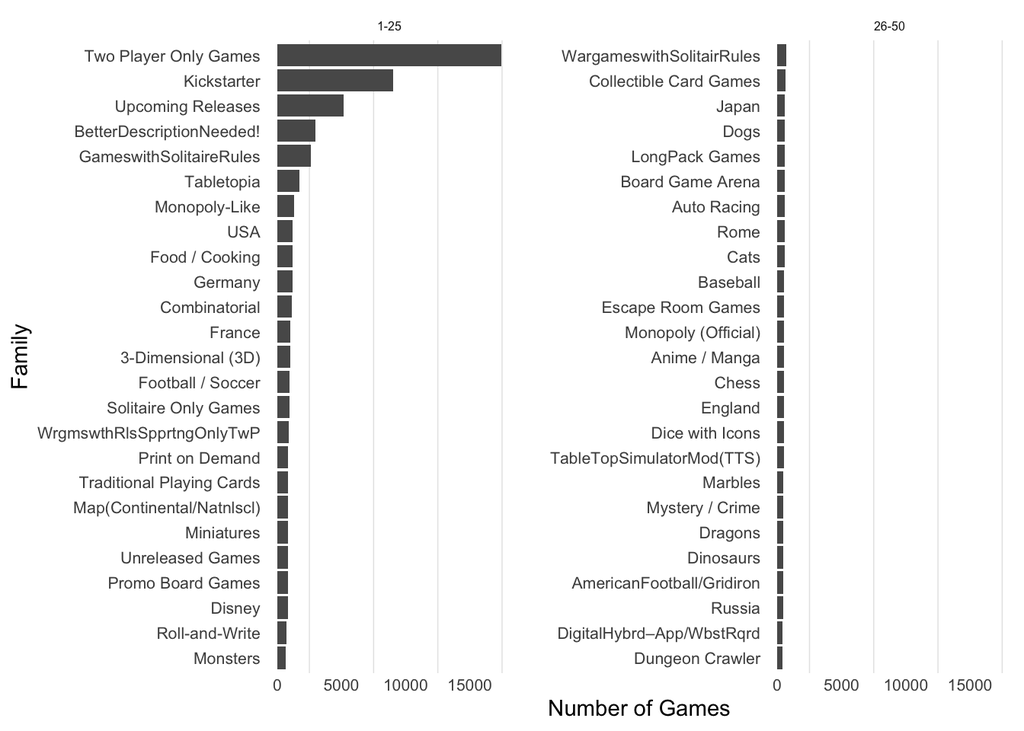

For BGG *family* variables, we can consider the hierarchy

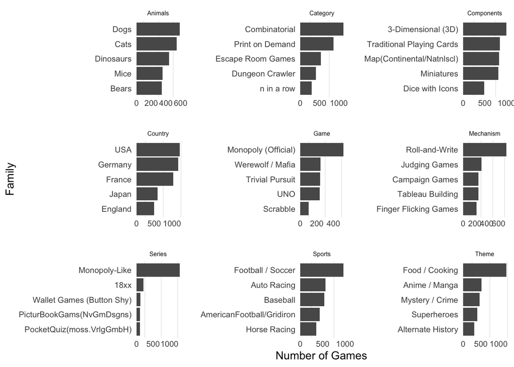

## 1.2 Families by BGG Outcome

How are games within each family typically rated?

I’ll then plot the distribution of games with the 25 most frequent families. What types of families are typically associated with heavier games? What family is the highest rated (on average)?

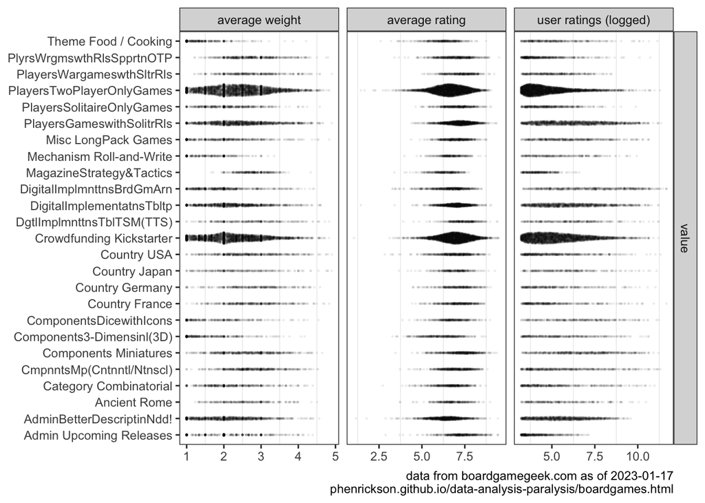

Finally, the following (interactive) table displays the mean of each BGG outcome by family. Use the filters below the column names to filter through the table by family or number of games.

[interactive table not shown]

## 1.3 Combinations of Families

What are the most frequent pairings of families in games on BGG? The following visualization displays an upset plot of the most frequent combinations of families used in games.

The bar chart on the bottom left indicates the number of games in each family. The bar chart on the top indicates the number of games with a **combination** of families.

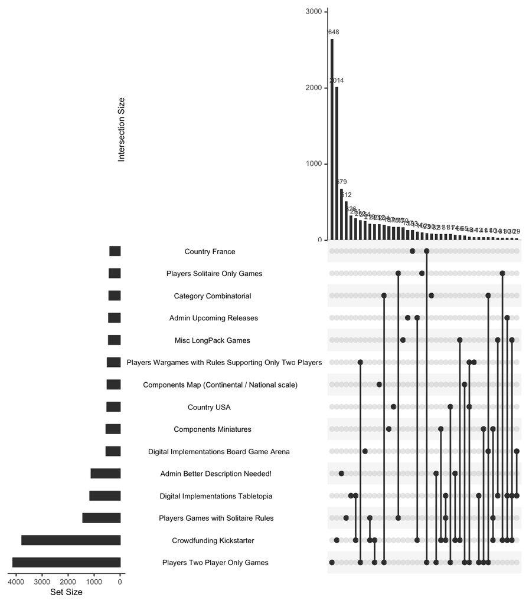